# Assignment 4: Spatial Predictive Analysis

Author

Zimu DENG (Mark)

Published

November 23, 2025

## Assignment Overview

In this lab, I will apply the spatial predictive modeling techniques demonstrated in the class exercise to a 311 service request type of my choice. I will build a complete spatial predictive model, document your process, and interpret my results.

**Learning Objectives:** - Adapt example code to analyze a new dataset - Build spatial features for predictive modeling - Apply count regression techniques to spatial data - Implement spatial cross-validation - Interpret and communicate model results - Critically evaluate model performance

## Setup

```r
# Load required packages
library(tidyverse)      # Data manipulation
library(sf)             # Spatial operations
library(here)           # Relative file paths
library(viridis)        # Color scales
library(terra)          # Raster operations (replaces 'raster')
library(spdep)          # Spatial dependence
library(FNN)            # Fast nearest neighbors
library(MASS)           # Negative binomial regression
library(patchwork)      # Plot composition (replaces grid/gridExtra)
library(knitr)          # Tables
library(kableExtra)     # Table formatting
library(classInt)       # Classification intervals
library(here)

# Spatstat split into sub-packages
library(spatstat.geom)    # Spatial geometries
library(spatstat.explore) # Spatial exploration/KDE

# Set options
options(scipen = 999)  # No scientific notation
set.seed(5080)         # Reproducibility

# Create consistent theme for visualizations
theme_crime <- function(base_size = 11) {
  theme_minimal(base_size = base_size) +
    theme(
      plot.title = element_text(face = "bold", size = base_size + 1),
      plot.subtitle = element_text(color = "gray30", size = base_size - 1),
      legend.position = "right",
      panel.grid.minor = element_blank(),
      axis.text = element_blank(),
      axis.title = element_blank()
    )
}

# Set as default
theme_set(theme_crime())

cat("✓ All packages loaded successfully!\n")
```

```
✓ All packages loaded successfully!
```

```r
cat("✓ Working directory:", getwd(), "\n")
```

```
✓ Working directory: F:/Upenn/MUSA 5080 Public Policy Analytics/portfolio-setup-MarkD12138/assignments/assignment_4
```

## Step 1: My 311 Violation Type

I chose the 311 service request type “Alley Light Out” as my violation because it provides a useful proxy for local guardianship and physical disorder when predicting burglaries. Reports of broken or non-functioning alley lights indicate areas that are poorly illuminated and less visible to neighbors or passers-by. From an environmental criminology perspective, these darker, less supervised micro-environments reduce natural surveillance and increase offenders’ perceived anonymity, making nearby properties more attractive targets for break-ins. Thus, the spatial pattern of alley-light-out complaints can reasonably be expected to correlate with higher burglary risk.

## Step 2: My Analysis

#### Part 1: Data Loading & Exploration

```r
# Load 311 data (Alley lights out)
alley_lights <- read_csv("data/311_Alley_Lights_Out_2017.csv")%>%
  filter(!is.na(Latitude), !is.na(Longitude)) %>%
  st_as_sf(coords = c("Longitude", "Latitude"), crs = 4326) %>%
  st_transform('ESRI:102271')
```

```r
# Load police districts (used for spatial cross-validation)
policeDistricts <-
  st_read("https://data.cityofchicago.org/api/geospatial/24zt-jpfn?method=export&format=GeoJSON") %>%
  st_transform('ESRI:102271') %>%
  dplyr::select(District = dist_num)
# Load police beats (smaller administrative units)
policeBeats <-
  st_read("https://data.cityofchicago.org/api/geospatial/n9it-hstw?method=export&format=GeoJSON") %>%
  st_transform('ESRI:102271') %>%
  dplyr::select(Beat = beat_num)
# Load Chicago boundary
chicagoBoundary <-
  st_read("https://raw.githubusercontent.com/urbanSpatial/Public-Policy-Analytics-Landing/master/DATA/Chapter5/chicagoBoundary.geojson") %>%
  st_transform('ESRI:102271')
cat("✓ Loaded spatial boundaries\n")
```

```
✓ Loaded spatial boundaries
```

```r
cat("  - Police districts:", nrow(policeDistricts), "\n")
```

```
  - Police districts: 25
```

```r
cat("  - Police beats:", nrow(policeBeats), "\n")
```

```
  - Police beats: 277
```

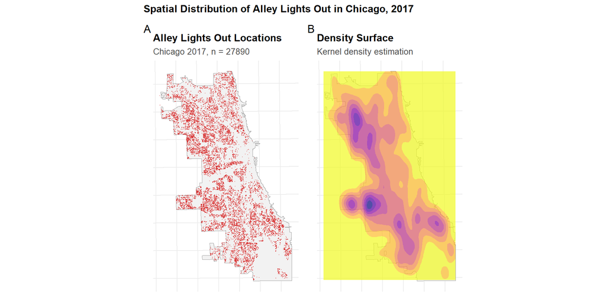

```r
## Visualization and Spatial Distribution
# Simple point map
p1 <- ggplot() +
  geom_sf(data = chicagoBoundary, fill = "gray95", color = "gray60") +
  geom_sf(data = alley_lights, color = "#d62828", size = 0.1, alpha = 0.4) +
  labs(
    title = "Alley Lights Out Locations",
    subtitle = paste0("Chicago 2017, n = ", nrow(alley_lights))
  )

# Density surface using modern syntax
p2 <- ggplot() +
  geom_sf(data = chicagoBoundary, fill = "gray95", color = "gray60") +
  geom_density_2d_filled(
    data = data.frame(st_coordinates(alley_lights)),
    aes(X, Y),
    alpha = 0.7,
    bins = 8
  ) +
  scale_fill_viridis_d(
    option = "plasma",
    direction = -1,
    guide = "none"  # Modern ggplot2 syntax (not guide = FALSE)
  ) +
  labs(
    title = "Density Surface",
    subtitle = "Kernel density estimation"
  )

# Combine plots using patchwork (modern approach)
p1 + p2 +
  plot_annotation(
    title = "Spatial Distribution of Alley Lights Out in Chicago, 2017",
    tag_levels = 'A'
  )
```

Spatial Pattern: The maps show that alley-light-out reports are not evenly distributed across Chicago, but cluster in a few broad corridors. Complaints are most concentrated in a north–south band through the western and southwestern residential neighborhoods, with several pronounced hotspots in the central and South Side areas. In contrast, the lakefront, downtown core, and some far-north and far-south edges have relatively few reports, suggesting better lighting conditions or fewer alleys in those parts of the city.

#### Part 2: Fishnet Grid Creation

```r
# Create 500m x 500m grid
fishnet_raw <- st_make_grid(
  chicagoBoundary,
  cellsize = 500,  # 500 meters per cell
  square = TRUE
) %>%
  st_sf() %>%
  mutate(uniqueID = row_number())

# Keep only cells that intersect Chicago
fishnet_raw <- fishnet_raw[chicagoBoundary, ]

# View basic info
cat("✓ Created fishnet grid\n")
```

```
✓ Created fishnet grid
```

```r
cat("  - Number of cells:", nrow(fishnet_raw), "\n")
```

```
  - Number of cells: 2458
```

```r
cat("  - Cell size:", 500, "x", 500, "meters\n")
```

```
  - Cell size: 500 x 500 meters
```

```r
cat("  - Cell area:", round(st_area(fishnet_raw[1,])), "square meters\n")
```

```
  - Cell area: 250000 square meters
```

```r
# Spatial join
alley_lights_fishnet <- st_join(alley_lights, fishnet_raw, join = st_within) %>%
  st_drop_geometry() %>%
  group_by(uniqueID) %>%
  summarize(countAlleyLights = n())

# Join back to fishnet (cells with 0 will be NA)
fishnet_raw <- fishnet_raw %>%
  left_join(alley_lights_fishnet, by = "uniqueID") %>%
  mutate(countAlleyLights = replace_na(countAlleyLights, 0))

# Summary statistics
cat("\nAlleyLights count distribution:\n")
```

```
AlleyLights count distribution:
```

```r
summary(fishnet_raw$countAlleyLights)
```

```
   Min. 1st Qu.  Median    Mean 3rd Qu.    Max.
   0.00    1.00    7.00   11.35   17.00  217.00
```

```r
cat("\nCells with zero AlleyLights:",
    sum(fishnet_raw$countAlleyLights == 0),
    "/", nrow(fishnet_raw),
    "(", round(100 * sum(fishnet_raw$countAlleyLights == 0) / nrow(fishnet_raw), 1), "%)\n")
```

```
Cells with zero AlleyLights: 597 / 2458 ( 24.3 %)
```

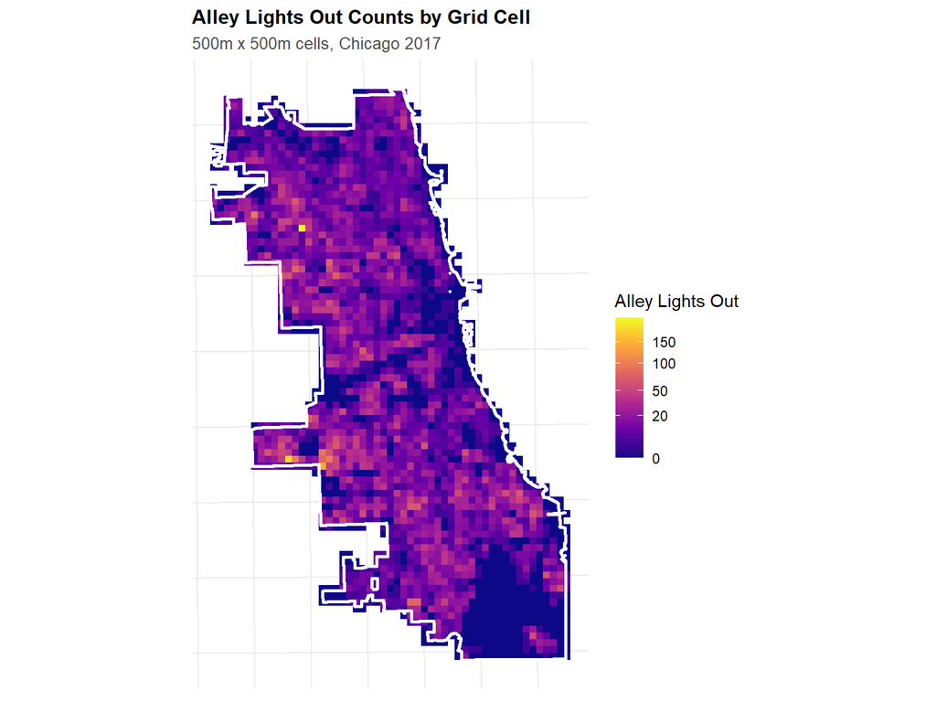

```r
# Visualize aggregated counts
ggplot() +
  geom_sf(data = fishnet_raw, aes(fill = countAlleyLights), color = NA) +
  geom_sf(data = chicagoBoundary, fill = NA, color = "white", linewidth = 1) +
  scale_fill_viridis_c(
    name = "Alley Lights Out",
    option = "plasma",
    trans = "sqrt",  # Square root for better visualization of skewed data
    breaks = c(0, 20, 50, 100, 150)
  ) +
  labs(
    title = "Alley Lights Out Counts by Grid Cell",
    subtitle = "500m x 500m cells, Chicago 2017"
  ) +
  theme_crime()
```

#### Part 3: Spatial Features

```r
## Calculate k-nearest neighbor features

# Get coordinates
fishnet_coords <- st_coordinates(st_centroid(fishnet_raw))
lights_coords <- st_coordinates(alley_lights)

# Calculate k nearest neighbors and distances
nn_result <- get.knnx(lights_coords, fishnet_coords, k = 3)

# Add to fishnet
fishnet <- fishnet_raw %>%
  mutate(
    alley_lights.nn = rowMeans(nn_result$nn.dist)
  )

cat("✓ Calculated nearest neighbor distances\n")
```

```
✓ Calculated nearest neighbor distances
```

```r
summary(fishnet$alley_lights.nn)
```

```
    Min.  1st Qu.   Median     Mean  3rd Qu.     Max.
   4.602  102.009  172.653  295.489  328.127 2313.532
```

```r
## Local Moran'I

# Function to calculate Local Moran's I
calculate_local_morans <- function(data, variable, k = 5) {

  # Create spatial weights
  coords <- st_coordinates(st_centroid(data))
  neighbors <- knn2nb(knearneigh(coords, k = k))
  weights <- nb2listw(neighbors, style = "W", zero.policy = TRUE)

  # Calculate Local Moran's I
  local_moran <- localmoran(data[[variable]], weights)

  # Classify clusters
  mean_val <- mean(data[[variable]], na.rm = TRUE)

  data %>%
    mutate(
      local_i = local_moran[, 1],
      p_value = local_moran[, 5],
      is_significant = p_value < 0.05,

      moran_class = case_when(
        !is_significant ~ "Not Significant",
        local_i > 0 & .data[[variable]] > mean_val ~ "High-High",
        local_i > 0 & .data[[variable]] <= mean_val ~ "Low-Low",
        local_i < 0 & .data[[variable]] > mean_val ~ "High-Low",
        local_i < 0 & .data[[variable]] <= mean_val ~ "Low-High",
        TRUE ~ "Not Significant"
      )
    )
}

# Apply function
fishnet <- calculate_local_morans(fishnet, "countAlleyLights", k = 5)
```

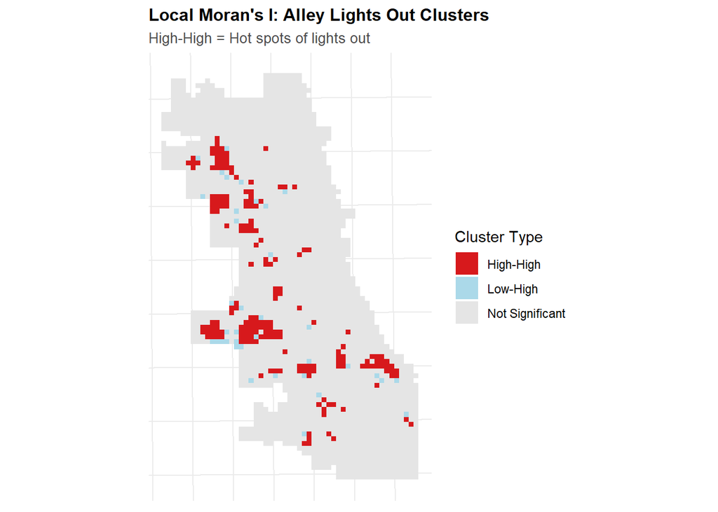

```r
## Identify Hot Spot

#| fig-width: 8
#| fig-height: 6

# Visualize hot spots
ggplot() +
  geom_sf(
    data = fishnet,
    aes(fill = moran_class),
    color = NA
  ) +
  scale_fill_manual(
    values = c(
      "High-High" = "#d7191c",
      "High-Low" = "#fdae61",
      "Low-High" = "#abd9e9",
      "Low-Low" = "#2c7bb6",
      "Not Significant" = "gray90"
    ),
    name = "Cluster Type"
  ) +
  labs(
    title = "Local Moran's I: Alley Lights Out Clusters",
    subtitle = "High-High = Hot spots of lights out"
  ) +
  theme_crime()
```

Interpretation: The Local Moran’s I results show that alley-light-out complaints are not randomly distributed, but form several statistically significant clusters. High–High cells (in red) – grid cells with high numbers of outages surrounded by similarly high neighbors – concentrate in contiguous bands in the central–west and southwest parts of the city, with additional pockets on the South Side. These areas represent local hot spots of poor alley lighting conditions. A few Low–High cells (in blue) appear on the edges of these clusters, indicating outliers. Most of the remaining grid cells are not significant.

```r
## Distance-to-hotspots

# Get centroids of "High-High" cells (hot spots)
hotspots <- fishnet %>%
  filter(moran_class == "High-High") %>%
  st_centroid()

# Calculate distance from each cell to nearest hot spot
if (nrow(hotspots) > 0) {
  fishnet <- fishnet %>%
    mutate(
      dist_to_hotspot = as.numeric(
        st_distance(st_centroid(fishnet), hotspots %>% st_union())
      )
    )

  cat("✓ Calculated distance to alley lights out hot spots\n")
  cat("  - Number of hot spot cells:", nrow(hotspots), "\n")
} else {
  fishnet <- fishnet %>%
    mutate(dist_to_hotspot = 0)
  cat("⚠ No significant hot spots found\n")
}
```

```
✓ Calculated distance to alley lights out hot spots
  - Number of hot spot cells: 193
```

#### Part 4: Count Regression Models

```r
## load-burglaries

#| message: false

# Load from provided data file (downloaded from Chicago open data portal)
burglaries <- st_read("data/burglaries.shp") %>%
  st_transform('ESRI:102271')
# Check the data
cat("\n✓ Loaded burglary data\n")
```

```
✓ Loaded burglary data
```

```r
cat("  - Number of burglaries:", nrow(burglaries), "\n")
```

```
  - Number of burglaries: 7482
```

```r
cat("  - CRS:", st_crs(burglaries)$input, "\n")
```

```
  - CRS: ESRI:102271
```

```r
cat("  - Date range:", min(burglaries$date, na.rm = TRUE), "to",
    max(burglaries$date, na.rm = TRUE), "\n")
```

```
  - Date range: Inf to -Inf
```

```r
## Aggregate burglary data to fishnet

# Spatial join: which cell contains each burglary?
burglaries_fishnet <- st_join(burglaries, fishnet, join = st_within) %>%
  st_drop_geometry() %>%
  group_by(uniqueID) %>%
  summarize(countBurglaries = n())

# Join back to fishnet (cells with 0 burglaries will be NA)
fishnet <- fishnet %>%
  left_join(burglaries_fishnet, by = "uniqueID") %>%
  mutate(countBurglaries = replace_na(countBurglaries, 0))

# Summary statistics
cat("\nBurglary count distribution:\n")
```

```
Burglary count distribution:
```

```r
summary(fishnet$countBurglaries)
```

```
   Min. 1st Qu.  Median    Mean 3rd Qu.    Max.
  0.000   0.000   2.000   3.042   5.000  40.000
```

```r
cat("\nCells with zero burglaries:",
    sum(fishnet$countBurglaries == 0),
    "/", nrow(fishnet),
    "(", round(100 * sum(fishnet$countBurglaries == 0) / nrow(fishnet), 1), "%)\n")
```

```
Cells with zero burglaries: 781 / 2458 ( 31.8 %)
```

```r
## KDE

#| message: false

# Convert burglaries to ppp (point pattern) format for spatstat
burglaries_ppp <- as.ppp(
  st_coordinates(burglaries),
  W = as.owin(st_bbox(chicagoBoundary))
)

# Calculate KDE with 1km bandwidth
kde_burglaries <- density.ppp(
  burglaries_ppp,
  sigma = 1000,  # 1km bandwidth
  edge = TRUE    # Edge correction
)

# Convert to terra raster (modern approach, not raster::raster)
kde_raster <- rast(kde_burglaries)

# Extract KDE values to fishnet cells
fishnet <- fishnet %>%
  mutate(
    kde_value = terra::extract(
      kde_raster,
      vect(fishnet),
      fun = mean,
      na.rm = TRUE
    )[, 2]  # Extract just the values column
  )

cat("✓ Calculated KDE baseline\n")
```

```
✓ Calculated KDE baseline
```

```r
# Join district information to fishnet
fishnet <- st_join(
  fishnet,
  policeDistricts,
  join = st_within,
  left = TRUE
) %>%
  filter(!is.na(District))  # Remove cells outside districts

cat("✓ Joined police districts\n")
```

```
✓ Joined police districts
```

```r
cat("  - Districts:", length(unique(fishnet$District)), "\n")
```

```
  - Districts: 22
```

```r
cat("  - Cells:", nrow(fishnet), "\n")
```

```
  - Cells: 1708
```

```r
## Fit Poisson regression
# Create clean modeling dataset
fishnet_model <- fishnet %>%
  st_drop_geometry() %>%
  dplyr::select(
    uniqueID,
    District,
    countBurglaries,
    countAlleyLights,
    alley_lights.nn,
    dist_to_hotspot
  ) %>%
  na.omit()  # Remove any remaining NAs

#Poisson regression
model_poisson <- glm(
  countBurglaries ~ countAlleyLights + alley_lights.nn + dist_to_hotspot,
  data = fishnet_model,
  family = "poisson"
)

# Summary
summary(model_poisson)
```

```
Call:
glm(formula = countBurglaries ~ countAlleyLights + alley_lights.nn +
    dist_to_hotspot, family = "poisson", data = fishnet_model)

Coefficients:
                    Estimate  Std. Error z value             Pr(>|z|)
(Intercept)       1.94834912  0.03567900  54.608 < 0.0000000000000002 ***
countAlleyLights  0.00272317  0.00078882   3.452             0.000556 ***
alley_lights.nn  -0.00338524  0.00014444 -23.437 < 0.0000000000000002 ***
dist_to_hotspot  -0.00010389  0.00001058  -9.822 < 0.0000000000000002 ***
---
Signif. codes:  0 '***' 0.001 '**' 0.01 '*' 0.05 '.' 0.1 ' ' 1

(Dispersion parameter for poisson family taken to be 1)

    Null deviance: 6710.3  on 1707  degrees of freedom
Residual deviance: 4963.8  on 1704  degrees of freedom
AIC: 9032.2

Number of Fisher Scoring iterations: 6
```

```r
# Calculate dispersion parameter
dispersion <- sum(residuals(model_poisson, type = "pearson")^2) /
              model_poisson$df.residual

cat("Dispersion parameter:", round(dispersion, 2), "\n")
```

```
Dispersion parameter: 3.25
```

```r
cat("Rule of thumb: >1.5 suggests overdispersion\n")
```

```
Rule of thumb: >1.5 suggests overdispersion
```

```r
if (dispersion > 1.5) {
  cat("⚠ Overdispersion detected! Consider Negative Binomial model.\n")
} else {
  cat("✓ Dispersion looks okay for Poisson model.\n")
}
```

```
⚠ Overdispersion detected! Consider Negative Binomial model.
```

```r
# Fit Negative Binomial model
model_nb <- glm.nb(
  countBurglaries ~ countAlleyLights + alley_lights.nn + dist_to_hotspot,
  data = fishnet_model
)

# Summary
summary(model_nb)
```

```
Call:
glm.nb(formula = countBurglaries ~ countAlleyLights + alley_lights.nn +
    dist_to_hotspot, data = fishnet_model, init.theta = 1.654963477,
    link = log)

Coefficients:
                    Estimate  Std. Error z value             Pr(>|z|)
(Intercept)       1.95361263  0.06651523  29.371 < 0.0000000000000002 ***
countAlleyLights  0.00352497  0.00169544   2.079               0.0376 *
alley_lights.nn  -0.00361395  0.00021646 -16.696 < 0.0000000000000002 ***
dist_to_hotspot  -0.00009261  0.00001807  -5.125          0.000000298 ***
---
Signif. codes:  0 '***' 0.001 '**' 0.01 '*' 0.05 '.' 0.1 ' ' 1

(Dispersion parameter for Negative Binomial(1.655) family taken to be 1)

    Null deviance: 2576.7  on 1707  degrees of freedom
Residual deviance: 1861.1  on 1704  degrees of freedom
AIC: 7556.5

Number of Fisher Scoring iterations: 1

              Theta:  1.6550
          Std. Err.:  0.0949

 2 x log-likelihood:  -7546.4900
```

```r
# Compare AIC (lower is better)
cat("\nModel Comparison:\n")
```

```
Model Comparison:
```

```r
cat("Poisson AIC:", round(AIC(model_poisson), 1), "\n")
```

```
Poisson AIC: 9032.2
```

```r
cat("Negative Binomial AIC:", round(AIC(model_nb), 1), "\n")
```

```
Negative Binomial AIC: 7556.5
```

#### Part 5: Spatial Cross-Validation (2017)

```r
# Get unique districts
districts <- unique(fishnet_model$District)
cv_results <- tibble()

cat("Running LOGO Cross-Validation...\n")
```

```
Running LOGO Cross-Validation...
```

```r
for (i in seq_along(districts)) {

  test_district <- districts[i]

  # Split data
  train_data <- fishnet_model %>% filter(District != test_district)
  test_data <- fishnet_model %>% filter(District == test_district)

  # Fit model on training data
  model_cv <- glm.nb(
    countBurglaries ~ countAlleyLights + alley_lights.nn + dist_to_hotspot,
    data = train_data
  )

  # Predict on test data
  test_data <- test_data %>%
    mutate(
      prediction = predict(model_cv, test_data, type = "response")
    )

  # Calculate metrics
  mae <- mean(abs(test_data$countBurglaries - test_data$prediction))
  rmse <- sqrt(mean((test_data$countBurglaries - test_data$prediction)^2))

  # Store results
  cv_results <- bind_rows(
    cv_results,
    tibble(
      fold = i,
      test_district = test_district,
      n_test = nrow(test_data),
      mae = mae,
      rmse = rmse
    )
  )

  cat("  Fold", i, "/", length(districts), "- District", test_district,
      "- MAE:", round(mae, 2), "\n")
}
```

```
  Fold 1 / 22 - District 5 - MAE: 1.95
  Fold 2 / 22 - District 4 - MAE: 1.84
  Fold 3 / 22 - District 22 - MAE: 2.4
  Fold 4 / 22 - District 6 - MAE: 3.08
  Fold 5 / 22 - District 8 - MAE: 3.24
  Fold 6 / 22 - District 7 - MAE: 2.96
  Fold 7 / 22 - District 3 - MAE: 5.87
  Fold 8 / 22 - District 2 - MAE: 2.8
  Fold 9 / 22 - District 9 - MAE: 2.03
  Fold 10 / 22 - District 10 - MAE: 2.33
  Fold 11 / 22 - District 1 - MAE: 2.34
  Fold 12 / 22 - District 12 - MAE: 3.29
  Fold 13 / 22 - District 15 - MAE: 1.88
  Fold 14 / 22 - District 11 - MAE: 2.87
  Fold 15 / 22 - District 18 - MAE: 2.39
  Fold 16 / 22 - District 25 - MAE: 2.5
  Fold 17 / 22 - District 14 - MAE: 2.75
  Fold 18 / 22 - District 19 - MAE: 2.07
  Fold 19 / 22 - District 16 - MAE: 2.38
  Fold 20 / 22 - District 17 - MAE: 1.78
  Fold 21 / 22 - District 20 - MAE: 1.8
  Fold 22 / 22 - District 24 - MAE: 2.02
```

```r
# Overall results
cat("\n✓ Cross-Validation Complete\n")
```

```
✓ Cross-Validation Complete
```

```r
cat("Mean MAE:", round(mean(cv_results$mae), 2), "\n")
```

```
Mean MAE: 2.57
```

```r
cat("Mean RMSE:", round(mean(cv_results$rmse), 2), "\n")
```

```
Mean RMSE: 3.49
```

Discussion: In this step I use spatial cross-validation, leaving out one police district at a time (LOGO CV). The reason for using a spatial CV scheme instead of random k-folds is that burglary patterns might be spatially autocorrelated: nearby cells look more similar than distant ones. A random split would mix neighboring cells across training and test sets, making the test data “too easy” and over-optimistic about model performance. By holding out an entire district, I can reveal how well does the model trained on some parts of Chicago generalize to a completely new area, which is a more robust way to test the prediction ability.

The results suggest that the model’s out-of-sample predictive ability is only low-moderate. The average MAE across folds is about 2.58 burglaries per grid cell, and the mean RMSE is 3.5, which are large. There is also substantial variation across districts: some folds have relatively low errors (MAE around 1.8–2.0), while others—such as District 3—show much higher errors (MAE above 5). This pattern indicates that the model captures some broad spatial structure, but its ability to generalize to all districts is limited, and performance degrades notably in certain areas.

#### Part 6: Model Evaluation (Spatial and Temporal)

#### Part 6.0 Use Final Model to Make Predictions

```r
final_model <- glm.nb(
  countBurglaries ~ countAlleyLights + alley_lights.nn + dist_to_hotspot,
  data = fishnet_model
)
```

```r
## Generate three predictors for 2018

# 0) Load 2018 311 data
alley_lights_2018 <- read_csv("data/311_Alley_Lights_Out_2018.csv")%>%
  filter(!is.na(Latitude), !is.na(Longitude)) %>%
  st_as_sf(coords = c("Longitude", "Latitude"), crs = 4326) %>%
  st_transform('ESRI:102271')

# 0) Prepare 500m x 500m grid for 2018
fishnet2 <- st_make_grid(
  chicagoBoundary,
  cellsize = 500,  # 500 meters per cell
  square = TRUE
) %>%
  st_sf() %>%
  mutate(uniqueID = row_number())

fishnet2 <- fishnet2[chicagoBoundary, ]

# 1) Aggregate into fishnet
alley_lights_fishnet_2018 <- st_join(alley_lights_2018, fishnet2, join = st_within) %>%
  st_drop_geometry() %>%
  group_by(uniqueID) %>%
  summarize(countAlleyLights = n())

# Join back to fishnet (cells with 0 will be NA)
fishnet2 <- fishnet2 %>%
  left_join(alley_lights_fishnet_2018, by = "uniqueID") %>%
  mutate(countAlleyLights = replace_na(countAlleyLights, 0))

# 2) Calculate k-nearest neighbor features
fishnet2_coords <- st_coordinates(st_centroid(fishnet2))
lights2018_coords <- st_coordinates(alley_lights_2018)

# Calculate k nearest neighbors and distances
nn_result2 <- get.knnx(lights2018_coords, fishnet2_coords, k = 3)

# Add to fishnet
fishnet2 <- fishnet2 %>%
  mutate(
    alley_lights.nn = rowMeans(nn_result2$nn.dist)
  )

# 3) Distance to hotspot
# Apply function
fishnet2 <- calculate_local_morans(fishnet2, "countAlleyLights", k = 5)

# Get centroids of "High-High" cells (hot spots)
hotspots <- fishnet2 %>%
  filter(moran_class == "High-High") %>%
  st_centroid()

if (nrow(hotspots) > 0) {
  fishnet2 <- fishnet2 %>%
    mutate(
      dist_to_hotspot = as.numeric(
        st_distance(st_centroid(fishnet2), hotspots %>% st_union())
      )
    )

  cat("✓ Calculated distance to alley lights out hot spots\n")
  cat("  - Number of hot spot cells:", nrow(hotspots), "\n")
} else {
  fishnet <- fishnet %>%
    mutate(dist_to_hotspot = 0)
  cat("⚠ No significant hot spots found\n")
}
```

```
✓ Calculated distance to alley lights out hot spots
  - Number of hot spot cells: 195
```

```r
## burglaries data for 2018
burglaries_2018 <- st_read("data/burglaries_2018.geojson") %>%
  st_transform('ESRI:102271')
```

```
replacing null geometries with empty geometries
Simple feature collection with 6647 features and 34 fields (with 33 geometries empty)
Geometry type: POINT
Dimension:     XY
Bounding box:  xmin: -87.84654 ymin: 41.64584 xmax: -87.52697 ymax: 42.02255
Geodetic CRS:  WGS 84
```

```r
# Spatial join
burglaries_fishnet2 <- st_join(burglaries_2018, fishnet2, join = st_within) %>%
  st_drop_geometry() %>%
  group_by(uniqueID) %>%
  summarize(countBurglaries = n())

# Join back to fishnet (cells with 0 burglaries will be NA)
fishnet2 <- fishnet2 %>%
  left_join(burglaries_fishnet2, by = "uniqueID") %>%
  mutate(countBurglaries = replace_na(countBurglaries, 0))

# Create clean dataset for prediction
fishnet_model_2018 <- fishnet2 %>%
  st_drop_geometry() %>%
  dplyr::select(
    uniqueID,
    countBurglaries,
    countAlleyLights,
    alley_lights.nn,
    dist_to_hotspot
  ) %>%
  na.omit()  # Remove any remaining NAs
```

```r
## Add predictions back to fishnet for both year

fishnet <- fishnet %>%
  mutate(
    prediction_nb = predict(final_model, fishnet_model, type = "response")[match(uniqueID, fishnet_model$uniqueID)]
  )

fishnet2 <- fishnet2 %>%
  mutate(
    prediction_nb = predict(final_model, fishnet_model_2018, type = "response")[match(uniqueID, fishnet_model_2018$uniqueID)]
  )

# KDE predictions as baseline (normalize to same scale as counts)
kde_sum <- sum(fishnet$kde_value, na.rm = TRUE)
count_sum <- sum(fishnet$countBurglaries, na.rm = TRUE)
fishnet <- fishnet %>%
  mutate(
    prediction_kde = (kde_value / kde_sum) * count_sum
  )
```

#### Part 6.1 Compare Model vs. KDE Baseline (Spatially)

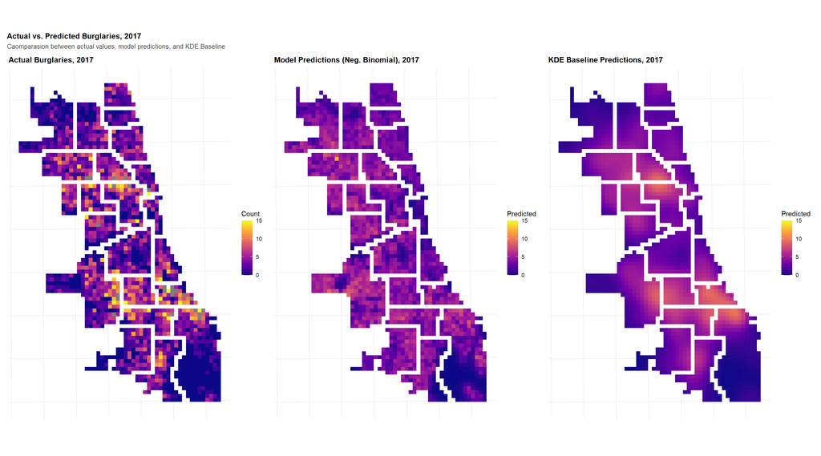

```r
# Create three maps

p1 <- ggplot() +
  geom_sf(data = fishnet, aes(fill = countBurglaries), color = NA) +
  scale_fill_viridis_c(name = "Count", option = "plasma", limits = c(0, 15)) +
  labs(title = "Actual Burglaries, 2017") +
  theme_crime()

p2 <- ggplot() +
  geom_sf(data = fishnet, aes(fill = prediction_nb), color = NA) +
  scale_fill_viridis_c(name = "Predicted", option = "plasma", limits = c(0, 15)) +
  labs(title = "Model Predictions (Neg. Binomial), 2017") +
  theme_crime()

p3 <- ggplot() +
  geom_sf(data = fishnet, aes(fill = prediction_kde), color = NA) +
  scale_fill_viridis_c(name = "Predicted", option = "plasma", limits = c(0, 15)) +
  labs(title = "KDE Baseline Predictions, 2017") +
  theme_crime()

p1 + p2 + p3 +
  plot_annotation(
    title = "Actual vs. Predicted Burglaries, 2017",
    subtitle = "Caomparasion between actual values, model predictions, and KDE Baseline"
  )
```

Discussion: Compared with actual plot, the Negative Binomial model reproduces the broad spatial pattern of burglaries in 2017. The model surface is clearly smoother than the real observations: many small, high-intensity hotspots in the actual map are muted or averaged out, and extreme peaks are under-predicted.

#### Part 6.2 Compare Model (Temporally)

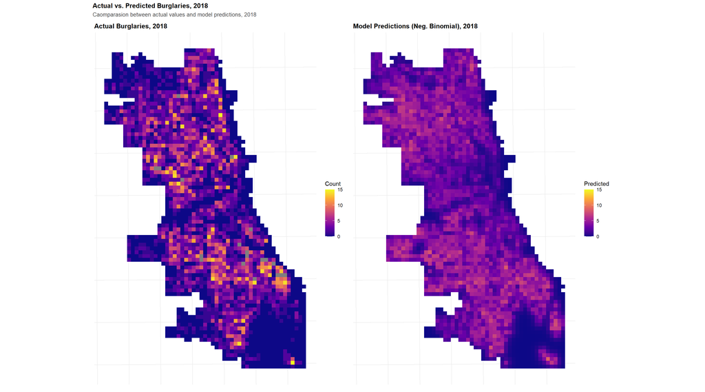

```r
# Create three maps

p4 <- ggplot() +
  geom_sf(data = fishnet2, aes(fill = countBurglaries), color = NA) +
  scale_fill_viridis_c(name = "Count", option = "plasma", limits = c(0, 15)) +
  labs(title = "Actual Burglaries, 2018") +
  theme_crime()

p5 <- ggplot() +
  geom_sf(data = fishnet2, aes(fill = prediction_nb), color = NA) +
  scale_fill_viridis_c(name = "Predicted", option = "plasma", limits = c(0, 15)) +
  labs(title = "Model Predictions (Neg. Binomial), 2018") +
  theme_crime()

p4 + p5 +
  plot_annotation(
    title = "Actual vs. Predicted Burglaries, 2018",
    subtitle = "Caomparasion between actual values and model predictions, 2018"
  )
```

Discussion: In the temporal validation for 2018, the Negative Binomial model again reproduces the broad spatial structure of burglaries, but the limitations of its predictive power are also apparent. The predicted surface correctly identifies the western and southern parts of the city as higher-risk areas and keeps the lakefront and far-south tip relatively low, so at a coarse scale the model generalizes reasonably well from 2017 to 2018. However, the 2018 predictions are even smoother and more diffuse than in the training year: many of the sharp, localized hotspots visible in the actual 2018 map are blurred into medium-intensity regions, and several newly emerging hotspots are clearly under-predicted.

#### Part 6.3 Map Prediction Errors for 2017 and 2018

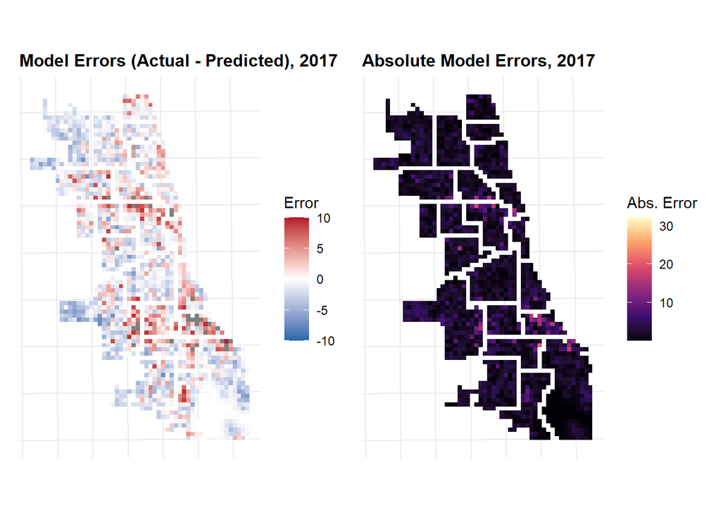

```r
## Map prediction errors for 2017 and 2018
# Calculate errors
fishnet <- fishnet %>%
  mutate(
    error_nb = countBurglaries - prediction_nb,
    error_kde = countBurglaries - prediction_kde,
    abs_error_nb = abs(error_nb),
    abs_error_kde = abs(error_kde)
  )

fishnet2 <- fishnet2 %>%
  mutate(
    error_nb = countBurglaries - prediction_nb,
    abs_error_nb = abs(error_nb),
  )

# Map errors
p6 <- ggplot() +
  geom_sf(data = fishnet, aes(fill = error_nb), color = NA) +
  scale_fill_gradient2(
    name = "Error",
    low = "#2166ac", mid = "white", high = "#b2182b",
    midpoint = 0,
    limits = c(-10, 10)
  ) +
  labs(title = "Model Errors (Actual - Predicted), 2017") +
  theme_crime()

p7 <- ggplot() +
  geom_sf(data = fishnet, aes(fill = abs_error_nb), color = NA) +
  scale_fill_viridis_c(name = "Abs. Error", option = "magma") +
  labs(title = "Absolute Model Errors, 2017") +
  theme_crime()



p6 + p7
```

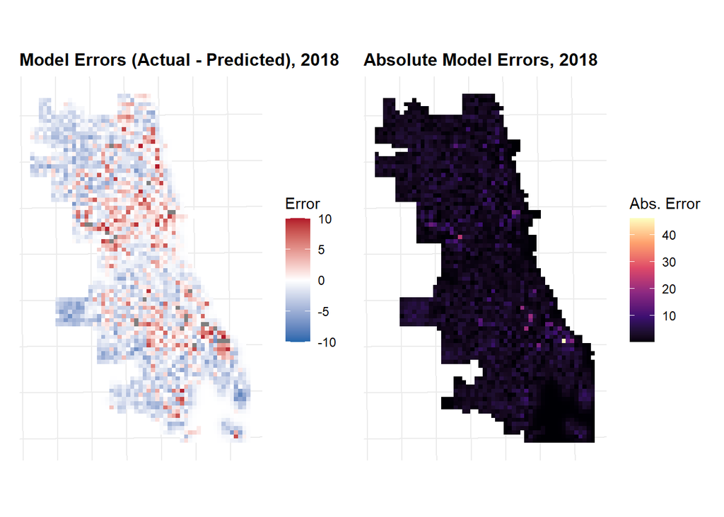

```r
# Map errors
p8 <- ggplot() +
  geom_sf(data = fishnet2, aes(fill = error_nb), color = NA) +
  scale_fill_gradient2(
    name = "Error",
    low = "#2166ac", mid = "white", high = "#b2182b",
    midpoint = 0,
    limits = c(-10, 10)
  ) +
  labs(title = "Model Errors (Actual - Predicted), 2018") +
  theme_crime()

p9 <- ggplot() +
  geom_sf(data = fishnet2, aes(fill = abs_error_nb), color = NA) +
  scale_fill_viridis_c(name = "Abs. Error", option = "magma") +
  labs(title = "Absolute Model Errors, 2018") +
  theme_crime()

p8 + p9
```

Discussion: Across both years, the error maps show clear local patterns of errors. In 2017, red cells (under-prediction) are concentrated in the main burglary hotspots in the north-western and southern parts of the city, where the model tends to miss the very highest counts. Blue cells (over-prediction) appear more often along the lakefront and some peripheral districts, where actual burglaries are close to zero but the model still assigns non-trivial risk. The absolute-error map confirms that the largest errors are clustered in these high-crime southern and southwestern areas.

In 2018, the pattern is similar. Cells show sightly lower absolute errors, but still a handful of high-burglary grids in the south stand out with large residuals. Overall, the model performs best in medium-risk areas and struggles most with extreme hotspots and very low-crime zones.

#### Part 6.4 Performance Metrics

```r
## Calculate performance metrics

comparison <- fishnet %>%
  st_drop_geometry() %>%
  filter(!is.na(prediction_nb), !is.na(prediction_kde)) %>%
  summarize(
    model_mae_2017 = mean(abs(countBurglaries - prediction_nb)),
    model_rmse_2017 = sqrt(mean((countBurglaries - prediction_nb)^2)),
    kde_mae = mean(abs(countBurglaries - prediction_kde)),
    kde_rmse = sqrt(mean((countBurglaries - prediction_kde)^2))
  )

comparison2 <- fishnet2 %>%
  st_drop_geometry() %>%
  filter(!is.na(prediction_nb)) %>%
  summarize(
    model_mae_2018 = mean(abs(countBurglaries - prediction_nb)),
    model_rmse_2018 = sqrt(mean((countBurglaries - prediction_nb)^2))
  )

perf_table <- tibble::tibble(
  Model = c(
    "KDE Baseline in 2017",
    "NegBin Model in 2017",
    "NegBin Model in 2018"
  ),
  MAE = c(
    comparison$kde_mae,#### Part 6.4 Performance Metrics
    comparison$model_mae_2017,
    comparison2$model_mae_2018
  ),
  RMSE = c(
    comparison$kde_rmse,
    comparison$model_rmse_2017,
    comparison2$model_rmse_2018
  )
)

perf_table %>%
  knitr::kable(
    digits = 2,
    caption = "Model Performance Comparison (2017 & 2018)"
  ) %>%
  kableExtra::kable_styling(
    bootstrap_options = c("striped", "hover")
  )
```

Model Performance Comparison (2017 & 2018)

| Model | MAE | RMSE |
| --- | --- | --- |
| KDE Baseline in 2017 | 2.06 | 2.95 |
| NegBin Model in 2017 | 2.43 | 3.49 |
| NegBin Model in 2018 | 2.17 | 3.19 |

Discussion: The performance table shows that the KDE baseline achieves the lowest error in the training year (2017), with MAE 2.06 and RMSE 2.95, while the Negative Binomial model performs slightly worse in 2017 (MAE 2.44, RMSE 3.50). This can be explained by that the KDE baseline is a purely spatial smoothing of the observed burglary counts, so it is very flexible and can closely reproduce the 2017 hotspot pattern, especially when evaluated on the same year it was built from. In contrast, the Negative Binomial model is more relies on a small set of features (alley lights and distance to hotspots) so it cannot capture all the local variation in the training data.

When the model is applied to 2018 for temporal validation, its error decreases (MAE 2.17, RMSE 3.18) compared with its 2017 performance, suggesting that its generalization ability is robust across years. Interestingly, the 2018 error is only slightly higher than the KDE baseline in 2017, but lower than the error in 2017. A likely explanation is that the 2018 burglary distribution itself is “easier” to predict. So a supplementary analysis might be required to see the difference of burglaries distribution between 2017 and 2018.

#### Part 6.5 Supplementary Analysis to Discuss the Difference of Burglaries between 2017 and 2018

```r
burg_all <- bind_rows(
  fishnet_model      %>% st_drop_geometry() %>% mutate(year = "2017"),
  fishnet_model_2018 %>% st_drop_geometry() %>% mutate(year = "2018")
)

burg_summary <- burg_all %>%
  group_by(year) %>%
  summarise(
    mean   = mean(countBurglaries, na.rm = TRUE),
    sd     = sd(countBurglaries, na.rm = TRUE),
    median = median(countBurglaries, na.rm = TRUE),
    p90    = quantile(countBurglaries, 0.9, na.rm = TRUE),
    max    = max(countBurglaries, na.rm = TRUE),
    prop_zero = mean(countBurglaries == 0, na.rm = TRUE)
  )

burg_summary
```

```
# A tibble: 2 × 7
  year   mean    sd median   p90   max prop_zero
  <chr> <dbl> <dbl>  <dbl> <dbl> <int>     <dbl>
1 2017   3.52  3.87      2     8    40     0.242
2 2018   2.69  3.44      2     7    51     0.338
```

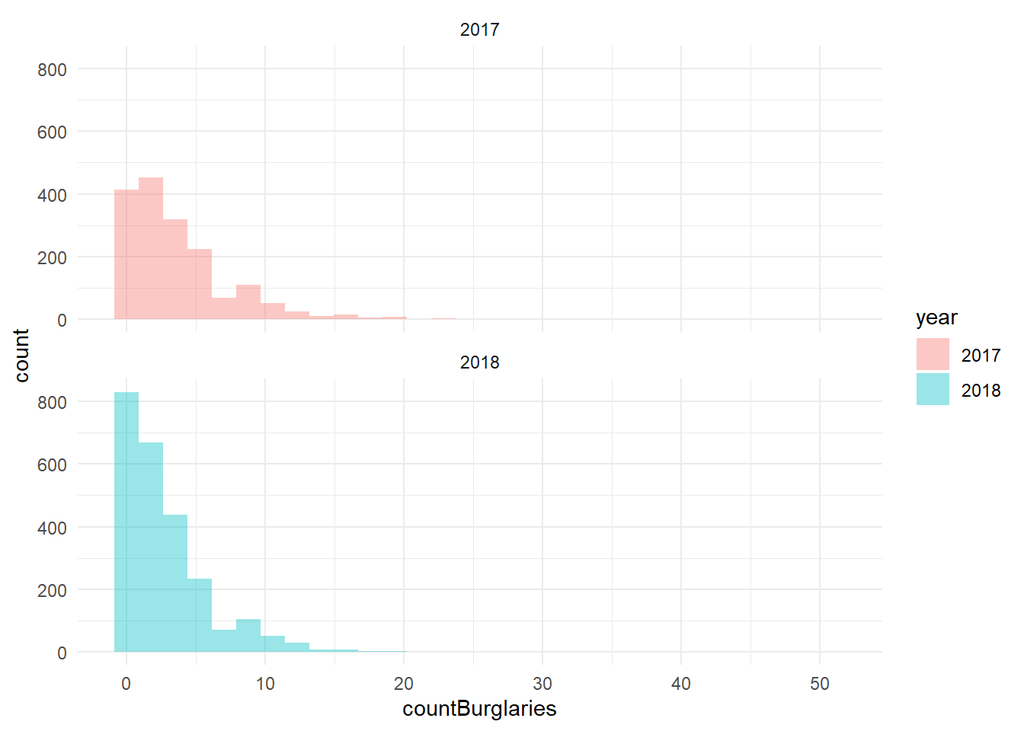

```r
# Histogram
ggplot(burg_all, aes(x = countBurglaries, fill = year)) +
  geom_histogram(position = "identity", alpha = 0.4, bins = 30) +
  scale_y_continuous() +
  facet_wrap(~ year, ncol = 1) +
  theme_minimal()
```

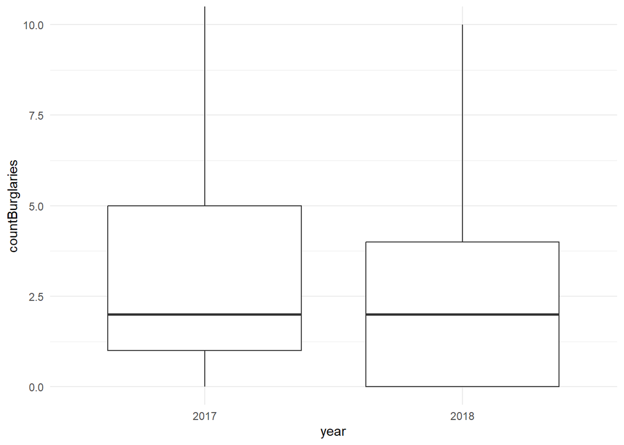

```r
# Box Plot
ggplot(burg_all, aes(x = year, y = countBurglaries)) +
  geom_boxplot() +
  coord_cartesian(ylim = c(0, quantile(burg_all$countBurglaries, 0.95))) +
  theme_minimal()
```

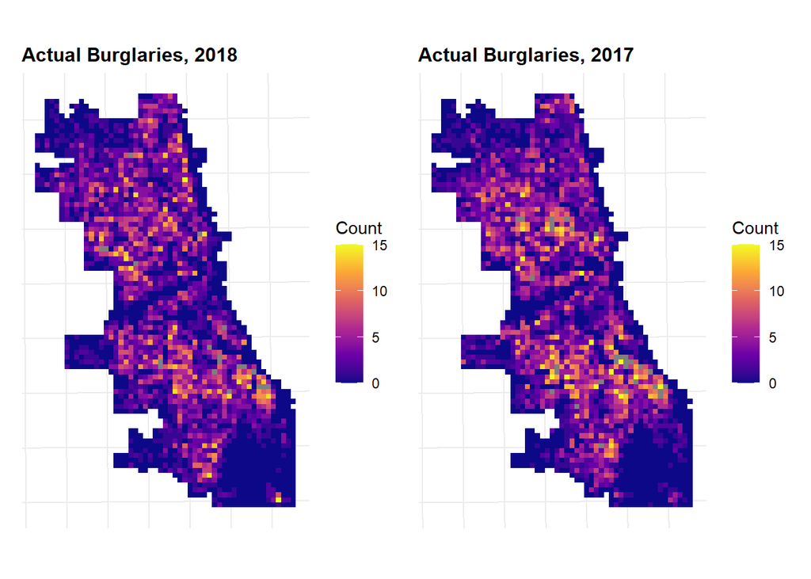

```r
p4 <- ggplot() +
  geom_sf(data = fishnet2, aes(fill = countBurglaries), color = NA) +
  scale_fill_viridis_c(name = "Count", option = "plasma", limits = c(0, 15)) +
  labs(title = "Actual Burglaries, 2018") +
  theme_crime()

burglaries_fishnet2 <- st_join(burglaries, fishnet_raw, join = st_within) %>%
  st_drop_geometry() %>%
  group_by(uniqueID) %>%
  summarize(countBurglaries = n())

fishnet_raw <- fishnet_raw %>%
  left_join(burglaries_fishnet, by = "uniqueID") %>%
  mutate(countBurglaries = replace_na(countBurglaries, 0))

p4.1 <- ggplot() +
  geom_sf(data = fishnet_raw, aes(fill = countBurglaries), color = NA) +
  scale_fill_viridis_c(name = "Count", option = "plasma", limits = c(0, 15)) +
  labs(title = "Actual Burglaries, 2017") +
  theme_crime()

p4 + p4.1
```

#### Part 6.6 Summary Table

```r
# Create nice summary table
model_summary <- broom::tidy(final_model, exponentiate = TRUE) %>%
  mutate(
    across(where(is.numeric), ~round(., 3))
  )

model_summary %>%
  kable(
    caption = "Final Negative Binomial Model Coefficients (Exponentiated)",
    col.names = c("Variable", "Rate Ratio", "Std. Error", "Z", "P-Value")
  ) %>%
  kable_styling(bootstrap_options = c("striped", "hover")) %>%
  footnote(
    general = "Rate ratios > 1 indicate positive association with burglary counts."
  )
```

Final Negative Binomial Model Coefficients (Exponentiated)

| Variable | Rate Ratio | Std. Error | Z | P-Value |
| --- | --- | --- | --- | --- |
| (Intercept) | 7.054 | 0.067 | 29.371 | 0.000 |
| countAlleyLights | 1.004 | 0.002 | 2.079 | 0.038 |
| alley_lights.nn | 0.996 | 0.000 | -16.696 | 0.000 |
| dist_to_hotspot | 1.000 | 0.000 | -5.125 | 0.000 |

Note:  
Rate ratios > 1 indicate positive association with burglary counts.

## Step 3: Conclusion

In this lab, I used 311 “Alley Lights Out” service requests as a proxy for local guardianship and physical disorder to model spatial patterns of burglaries in Chicago. I aggregated the data to a fishnet grid and constructed three spatial features: the count of alley-light-out reports in each cell, the average distance from each cell to its three nearest light-out events (a k-nearest-neighbor measure), and distance to light-out hotspots. Using these features, I fit Poisson and then Negative Binomial count regression models, compared the final Negative Binomial model to a KDE baseline in 2017, and evaluated its temporal robustness by predicting burglaries in 2018.

The results show that the regression model has limited predictive power. It captures the broad spatial structure of burglary risk—higher in the western and southern corridors and lower along the lakefront—but struggles with fine-grained variation and extreme hotspots. Error maps reveal systematic under-prediction in the most intense high-crime cells and over-prediction in very low-crime areas. In terms of performance metrics, the Negative Binomial model has higher MAE and RMSE than the 2017 KDE baseline, reflecting this smoother, less flexible fit. However, when applied to 2018, the model remains reasonably robust over time and even achieves slightly lower errors than in 2017, likely because the 2018 burglary distribution is less variable and contains fewer extreme peaks, making it easier to predict.

Finally, these findings need to consider the biases in 311 data. Service requests reflect not only physical conditions but also who chooses—and is able—to report problems. Historical patterns of disinvestment, unequal access to digital tools, language barriers, and varying levels of trust in local government all shape where 311 calls are made. As a result, alley-light-out complaints may under-represent infrastructure problems in some high-need neighborhoods and over-represent them in others. This reporting bias means that my model may systematically misstate conditions in marginalized communities and ultimately limit the accuracy and equity of the predictions.